# Caso Monopoly

### EDA Exploratory Data Analysis

```python
#Primeras lineas del DF
data.head()
```

| Id | Subsegmento | Sexo | Region | Edad | Renta | Antiguedad | Internauta | Adicional | Dualidad | Monoproducto | ... | ColMx_T01 | PagoNac_T01 | PagoInt_T01 | EeccNac_T01 | EeccInt_T01 | UsoL1_T01 | UsoL2_T01 | UsoLI_T01 | IndRev_T01 | target |
| --- | --- | --- | --- | --- | --- | --- | --- | --- | --- | --- | --- | --- | --- | --- | --- | --- | --- | --- | --- | --- | --- |
| 27778 | 210 | M | 9.0 | 28 | 436069.0 | 35 | 1 | 0 | 1 | 0 | ... | 0.0 | 14181 | 0.0 | 53539 | 0.0 | 53539.00 | 218399 | 0.0 | R | 0 |
| 37220 | 210 | H | 13.0 | 24 | 664366.0 | 20 | 1 | 0 | 0 | 0 | ... | 0.0 | 9000 | 0.0 | 246496 | 0.0 | 246496.00 | 115364 | 0.0 | R | 0 |
| 5289 | 210 | M | 12.0 | 28 | 485999.0 | 16 | 1 | 0 | 1 | 0 | ... | 0.0 | 20550 | 0.0 | 80823 | 0.0 | 79853.00 | 172986 | 0.0 | R | 0 |
| 24673 | 220 | H | NaN | 25 | NaN | 14 | 0 | 0 | 0 | 0 | ... | 0.0 | 0 | 0.0 | 15249 | 0.0 | 15249.00 | 6966 | 0.0 | R | 0 |
| 27929 | 220 | M | 4.0 | 27 | NaN | 14 | 0 | 0 | 0 | 0 | ... | 0.0 | 70000 | 0.0 | 93591 | 0.0 | 36311.63 | 17949 | 0.0 | R | 0 |

5 rows × 573 columns

```python
dfnuevo= datosUsuariEnero(data)
dfnuevo
```

| Id | Subsegmento | Sexo | Region | Edad | Renta | Antiguedad | Internauta | Adicional | Dualidad | Monoproducto | ... | ColMx_T01 | PagoNac_T01 | PagoInt_T01 | EeccNac_T01 | EeccInt_T01 | UsoL1_T01 | UsoL2_T01 | UsoLI_T01 | IndRev_T01 | target |
| --- | --- | --- | --- | --- | --- | --- | --- | --- | --- | --- | --- | --- | --- | --- | --- | --- | --- | --- | --- | --- | --- |
| 27778 | 210 | M | 9.0 | 28 | 436069.0 | 35 | 1 | 0 | 1 | 0 | ... | 0.0 | 14181 | 0.0 | 53539 | 0.0 | 53539.00 | 218399 | 0.0 | R | 0 |
| 37220 | 210 | H | 13.0 | 24 | 664366.0 | 20 | 1 | 0 | 0 | 0 | ... | 0.0 | 9000 | 0.0 | 246496 | 0.0 | 246496.00 | 115364 | 0.0 | R | 0 |
| 5289 | 210 | M | 12.0 | 28 | 485999.0 | 16 | 1 | 0 | 1 | 0 | ... | 0.0 | 20550 | 0.0 | 80823 | 0.0 | 79853.00 | 172986 | 0.0 | R | 0 |
| 24673 | 220 | H | NaN | 25 | NaN | 14 | 0 | 0 | 0 | 0 | ... | 0.0 | 0 | 0.0 | 15249 | 0.0 | 15249.00 | 6966 | 0.0 | R | 0 |
| 27929 | 220 | M | 4.0 | 27 | NaN | 14 | 0 | 0 | 0 | 0 | ... | 0.0 | 70000 | 0.0 | 93591 | 0.0 | 36311.63 | 17949 | 0.0 | R | 0 |
| ... | ... | ... | ... | ... | ... | ... | ... | ... | ... | ... | ... | ... | ... | ... | ... | ... | ... | ... | ... | ... | ... |
| 38406 | 220 | H | 13.0 | 22 | 88214.0 | 9 | 1 | 0 | 0 | 0 | ... | 0.0 | 0 | 0.0 | 41496 | 0.0 | 0.00 | 30184 | 0.0 | T | 0 |
| 7159 | 160 | H | 13.0 | 42 | 506029.0 | 34 | 1 | 0 | 0 | 0 | ... | 0.0 | 8000 | 0.0 | 254387 | 0.0 | 254387.00 | 0 | 0.0 | R | 0 |
| 9427 | 170 | H | 13.0 | 39 | 1181631.0 | 86 | 1 | 0 | 0 | 0 | ... | 0.0 | 30000 | 0.0 | 27182 | 0.0 | 27182.00 | 0 | 0.0 | R | 0 |
| 42142 | 160 | H | 8.0 | 60 | 346232.0 | 31 | 0 | 0 | 1 | 0 | ... | 0.0 | 5000 | 0.0 | 212699 | 0.0 | 212699.00 | 47272 | 0.0 | R | 1 |
| 5740 | 170 | M | 13.0 | 44 | 646476.0 | 84 | 1 | 0 | 1 | 0 | ... | 0.0 | 0 | 0.0 | 72033 | 0.0 | 72033.00 | 39052 | 0.0 | T | 0 |

5112 rows × 67 columns

```python
#Datos del DF
data.info()
```

```
<class 'pandas.core.frame.DataFrame'>
Int64Index: 5112 entries, 27778 to 5740
Columns: 573 entries, Subsegmento to target
dtypes: float64(505), int64(55), object(13)
memory usage: 22.4+ MB
```

```python
# Tamaño de Filas y Columnas del DF

data.shape
```

```
(5112, 573)
```

```python
#separacion de los datos por usuario y datos registros por mes

data_cliente,data_mensual = mon_column(data)
print(data_cliente.shape)
print(data_mensual.shape)
```

```
(5112, 21)
(5112, 552)
```

**Analis de datos de Clientes**

```python
#Atravez de la funcion Check se realiza un resumen del tipo de dato por columna,
# la cantidad de datos unicos, la cantidad de nulos, y el % de nulos respecto
# al total
check(data_cliente)
```

|  | column | dtypes | nunique | sum_null | percen_null |
| --- | --- | --- | --- | --- | --- |
| 0 | Subsegmento | int64 | 8 | 0 | 0.0000 |
| 1 | Sexo | object | 2 | 0 | 0.0000 |
| 2 | Region | float64 | 13 | 10 | 0.1956 |
| 3 | Edad | int64 | 72 | 0 | 0.0000 |
| 4 | Renta | float64 | 3561 | 1353 | 26.4671 |
| 5 | Antiguedad | int64 | 175 | 0 | 0.0000 |
| 6 | Internauta | int64 | 2 | 0 | 0.0000 |
| 7 | Adicional | int64 | 2 | 0 | 0.0000 |
| 8 | Dualidad | int64 | 2 | 0 | 0.0000 |
| 9 | Monoproducto | int64 | 2 | 0 | 0.0000 |
| 10 | Ctacte | int64 | 2 | 0 | 0.0000 |
| 11 | Consumo | int64 | 2 | 0 | 0.0000 |
| 12 | Hipotecario | int64 | 2 | 0 | 0.0000 |
| 13 | Debito | int64 | 2 | 0 | 0.0000 |
| 14 | CambioPin | float64 | 1 | 1921 | 37.5782 |
| 15 | Cuentas | int64 | 5 | 0 | 0.0000 |
| 16 | TC | int64 | 7 | 0 | 0.0000 |
| 17 | CUPO_L1 | int64 | 1490 | 0 | 0.0000 |
| 18 | CUPO_L2 | float64 | 715 | 0 | 0.0000 |
| 19 | CUPO_MX | int64 | 745 | 0 | 0.0000 |
| 20 | target | int64 | 2 | 0 | 0.0000 |

Se puede apreciar que en este tramo de datos existen tres columnas con datos nulos.

1. Región: Los nulos representan menos del 1 % de los datos, por lo que se pueden eliminar sin afectar significativamente el tamaño de la muestra.
2. Renta: Los nulos representan el 26 % de los datos, lo que es una proporción considerable. Para evitar que los datos faltantes afecten los resultados del análisis, se plantea imputarlos utilizando técnicas como MICE.
3. CambioPin: En este caso, los valores nulos se pueden interpretar como que el cliente no realizó el cambio de pin. Por lo tanto, se plantea reemplazarlos por el valor "0".

```python
#descripcion estadistica de los datos del cliente
data_cliente.describe()
```

|  | Subsegmento | Region | Edad | Renta | Antiguedad | Internauta | Adicional | Dualidad | Monoproducto | Ctacte | Consumo | Hipotecario | Debito | CambioPin | Cuentas | TC | CUPO_L1 | CUPO_L2 | CUPO_MX | target |
| --- | --- | --- | --- | --- | --- | --- | --- | --- | --- | --- | --- | --- | --- | --- | --- | --- | --- | --- | --- | --- |
| count | 5112.000000 | 5102.000000 | 5112.000000 | 3.759000e+03 | 5112.000000 | 5112.000000 | 5112.000000 | 5112.000000 | 5112.000000 | 5112.000000 | 5112.000000 | 5112.000000 | 5112.000000 | 3191.0 | 5112.000000 | 5112.000000 | 5.112000e+03 | 5.112000e+03 | 5112.000000 | 5112.000000 |
| mean | 181.839397 | 10.823795 | 38.787559 | 6.589134e+05 | 39.120696 | 0.680164 | 0.260172 | 0.369523 | 0.068466 | 0.920970 | 0.001565 | 0.139476 | 0.874804 | 1.0 | 1.391432 | 1.721440 | 1.116222e+06 | 3.219817e+05 | 1376.821401 | 0.090571 |
| std | 28.483270 | 3.389346 | 13.438289 | 3.967115e+05 | 36.290536 | 0.466458 | 0.438771 | 0.482723 | 0.252569 | 0.269812 | 0.039532 | 0.346476 | 0.330973 | 0.0 | 0.538436 | 0.862639 | 1.045975e+06 | 7.642932e+05 | 1573.067873 | 0.287026 |
| min | 151.000000 | 1.000000 | 19.000000 | 1.000000e+00 | 6.000000 | 0.000000 | 0.000000 | 0.000000 | 0.000000 | 0.000000 | 0.000000 | 0.000000 | 0.000000 | 1.0 | 1.000000 | 1.000000 | 5.000000e+04 | 0.000000e+00 | 0.000000 | 0.000000 |
| 25% | 160.000000 | 9.000000 | 28.000000 | 4.188580e+05 | 14.000000 | 0.000000 | 0.000000 | 0.000000 | 0.000000 | 1.000000 | 0.000000 | 0.000000 | 1.000000 | 1.0 | 1.000000 | 1.000000 | 4.000000e+05 | 1.000000e+03 | 300.000000 | 0.000000 |
| 50% | 170.000000 | 13.000000 | 35.000000 | 5.636170e+05 | 26.000000 | 1.000000 | 0.000000 | 0.000000 | 0.000000 | 1.000000 | 0.000000 | 0.000000 | 1.000000 | 1.0 | 1.000000 | 2.000000 | 8.000000e+05 | 1.000000e+05 | 1000.000000 | 0.000000 |
| 75% | 210.000000 | 13.000000 | 46.000000 | 8.068225e+05 | 54.000000 | 1.000000 | 1.000000 | 1.000000 | 0.000000 | 1.000000 | 0.000000 | 0.000000 | 1.000000 | 1.0 | 2.000000 | 2.000000 | 1.530000e+06 | 2.200000e+05 | 1831.500000 | 0.000000 |
| max | 811.000000 | 13.000000 | 93.000000 | 5.790824e+06 | 312.000000 | 1.000000 | 1.000000 | 1.000000 | 1.000000 | 1.000000 | 1.000000 | 1.000000 | 1.000000 | 1.0 | 5.000000 | 7.000000 | 1.049400e+07 | 1.116800e+07 | 19600.000000 | 1.000000 |

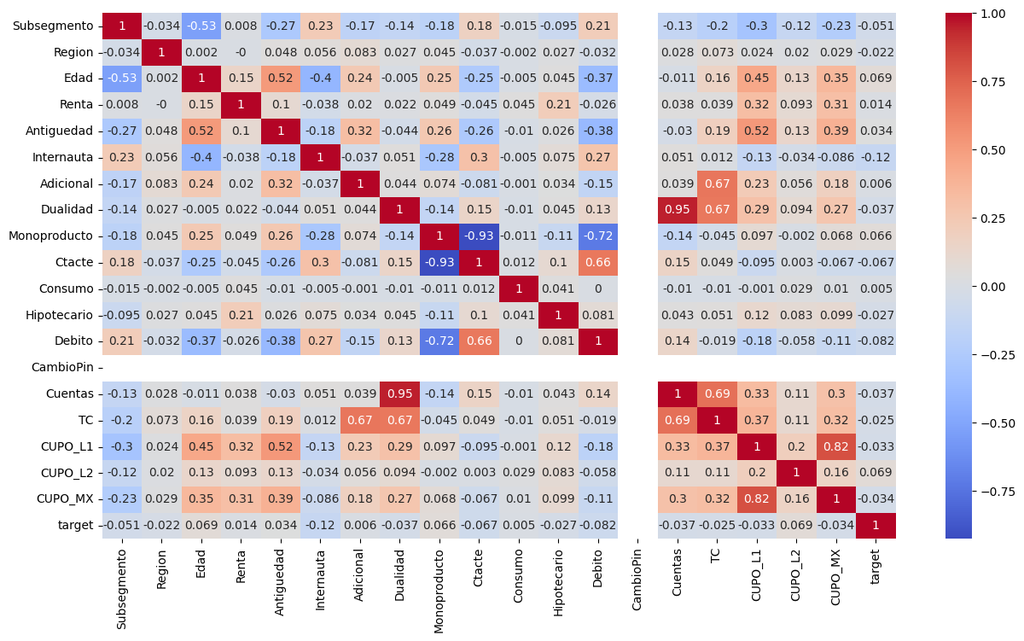

```python
#mapa de calor de correlaciones en datos de clientes
plt.figure(figsize = (15,8))
sb.heatmap(data_cliente.corr().round(3), cmap='coolwarm', annot=True)
plt.title="Mapa Calor"
plt.show()
```

```python
''' #Grafico de relacion entre variables
df_subset = data_cliente.sample(frac=0.02)
print(len(df_subset), df_subset.columns)
print(df_subset.shape)
sb.pairplot(df_subset) '''
```

```
' #Grafico de relacion entre variables\ndf_subset = data_cliente.sample(frac=0.02)\nprint(len(df_subset), df_subset.columns)\nprint(df_subset.shape)\nsb.pairplot(df_subset) '
```

**Analis de datos de registros por mes de Clientes**

```python
#Atravez de la funcion Check se realiza un resumen del tipo de dato por columna,
# la cantidad de datos unicos, la cantidad de nulos, y el % de nulos respecto
# al total
data_mensual_check=check(data_mensual)
data_mensual_check
```

|  | column | dtypes | nunique | sum_null | percen_null |
| --- | --- | --- | --- | --- | --- |
| 0 | FlgAct_T12 | float64 | 2 | 836 | 16.3537 |
| 1 | FlgActCN_T12 | float64 | 2 | 836 | 16.3537 |
| 2 | FlgActCI_T12 | float64 | 2 | 836 | 16.3537 |
| 3 | FlgActAN_T12 | float64 | 2 | 836 | 16.3537 |
| 4 | FlgActAI_T12 | float64 | 2 | 836 | 16.3537 |
| ... | ... | ... | ... | ... | ... |
| 547 | EeccInt_T01 | float64 | 305 | 0 | 0.0000 |
| 548 | UsoL1_T01 | float64 | 4435 | 0 | 0.0000 |
| 549 | UsoL2_T01 | int64 | 3314 | 0 | 0.0000 |
| 550 | UsoLI_T01 | float64 | 313 | 0 | 0.0000 |
| 551 | IndRev_T01 | object | 3 | 0 | 0.0000 |

552 rows × 5 columns

```python
#cantidad de columnas que continene datos nulos
len(data_mensual_check[data_mensual_check["sum_null"]>0])
```

```
506
```

```python
#cantidad de columnas que el % de nulos es mayor que el 10%
len(data_mensual_check[data_mensual_check["percen_null"]>10])
```

```
138
```

```python
#analizando datos de colunas IndRev_TXX del tipo Object
data["IndRev_T01"].unique()
```

```
array(['R', 'P', 'T'], dtype=object)
```

Se determina que existen 506 de 552 columnas con valores nulos.

Ademas, 138 columnas de 552 el % de nulos es mayor que el 10%.

Como los valores registrados en este tramos de la infomacion corresponde a numericos se pueden aplicar MICE para su imputacion.

Tambien se debe considerar realizar un transformacion previa en las columnas "IndRev_TXX" antes de la operacion sugerida.

```python
#Descripcion estadistica de los Registros mensuales de Enero

data_mensual.iloc[:,-46:].describe()
```

|  | FlgAct_T01 | FlgActCN_T01 | FlgActCI_T01 | FlgActAN_T01 | FlgActAI_T01 | FlgActPAT_T01 | FlgActCCPC_T01 | FlgActCCOT_T01 | FlgActCOL_T01 | Fac_T01 | ... | ColL2AC_T01 | ColL2CC_T01 | ColMx_T01 | PagoNac_T01 | PagoInt_T01 | EeccNac_T01 | EeccInt_T01 | UsoL1_T01 | UsoL2_T01 | UsoLI_T01 |
| --- | --- | --- | --- | --- | --- | --- | --- | --- | --- | --- | --- | --- | --- | --- | --- | --- | --- | --- | --- | --- | --- |
| count | 5112.000000 | 5112.00000 | 5112.000000 | 5112.000000 | 5112.000000 | 5112.000000 | 5112.000000 | 5112.000000 | 5112.000000 | 5.112000e+03 | ... | 5.112000e+03 | 5.112000e+03 | 5.112000e+03 | 5.112000e+03 | 5.112000e+03 | 5.112000e+03 | 5112.000000 | 5.112000e+03 | 5.112000e+03 | 5112.000000 |
| mean | 0.664710 | 0.58529 | 0.040102 | 0.030908 | 0.001956 | 0.133803 | 0.286972 | 0.101526 | 0.001565 | 7.163727e+04 | ... | 6.247437e+04 | 4.107607e+04 | 5.530910e+03 | 7.264162e+04 | 1.208558e+03 | 1.913094e+05 | 7.596050 | 1.817260e+05 | 1.291747e+05 | 8.987338 |
| std | 0.472138 | 0.49272 | 0.196217 | 0.173085 | 0.044190 | 0.340474 | 0.452393 | 0.302053 | 0.039532 | 1.412821e+05 | ... | 4.203266e+05 | 9.948940e+04 | 5.674680e+04 | 1.379294e+05 | 2.532578e+04 | 2.845051e+05 | 122.800419 | 2.863325e+05 | 4.320962e+05 | 126.358721 |
| min | 0.000000 | 0.00000 | 0.000000 | 0.000000 | 0.000000 | 0.000000 | 0.000000 | 0.000000 | 0.000000 | -1.199000e+05 | ... | 0.000000e+00 | 0.000000e+00 | 0.000000e+00 | 0.000000e+00 | 0.000000e+00 | -8.769960e+05 | -4885.000000 | -8.769960e+05 | -2.000000e+00 | -4652.500000 |
| 25% | 0.000000 | 0.00000 | 0.000000 | 0.000000 | 0.000000 | 0.000000 | 0.000000 | 0.000000 | 0.000000 | 0.000000e+00 | ... | 0.000000e+00 | 0.000000e+00 | 0.000000e+00 | 5.000000e+03 | 0.000000e+00 | 3.128575e+04 | 0.000000 | 1.664075e+04 | 0.000000e+00 | 0.000000 |
| 50% | 1.000000 | 1.00000 | 0.000000 | 0.000000 | 0.000000 | 0.000000 | 0.000000 | 0.000000 | 0.000000 | 2.779750e+04 | ... | 0.000000e+00 | 0.000000e+00 | 0.000000e+00 | 3.300000e+04 | 0.000000e+00 | 9.074350e+04 | 0.000000 | 7.974000e+04 | 2.851650e+04 | 0.000000 |
| 75% | 1.000000 | 1.00000 | 0.000000 | 0.000000 | 0.000000 | 0.000000 | 1.000000 | 0.000000 | 0.000000 | 8.845400e+04 | ... | 0.000000e+00 | 4.008150e+04 | 0.000000e+00 | 8.891975e+04 | 0.000000e+00 | 2.364485e+05 | 0.000000 | 2.276278e+05 | 9.524400e+04 | 0.000000 |
| max | 1.000000 | 1.00000 | 1.000000 | 1.000000 | 1.000000 | 1.000000 | 1.000000 | 1.000000 | 1.000000 | 2.793659e+06 | ... | 1.013884e+07 | 1.472740e+06 | 1.762587e+06 | 3.066190e+06 | 1.225290e+06 | 3.202962e+06 | 3341.650000 | 3.511191e+06 | 1.000609e+07 | 3341.650000 |

8 rows × 45 columns

```python
''' #mapa de calor de correlaciones en los Registros mensuales de Enero
plt.figure(figsize = (30,30))
sb.heatmap(data_mensual.iloc[:,-46:].corr().round(3), cmap='coolwarm', annot=True)
plt.title="Mapa Calor"
plt.show() '''
```

[output not shown]

```python
''' ##Grafico de relacion entre variables
df_subset2 = data_mensual.iloc[:,-46:].sample(frac=0.02)
print(len(df_subset2), df_subset2.columns)
print(df_subset2.shape)
sb.pairplot(df_subset2) '''
```

[output not shown]

## Fase 3: Data Preparation

### **imputacion**

```python
#se remplazan los nulos por "0" en la columna "CambioPin"
data_imputada_CP= data.copy()
data_imputada_CP["CambioPin"].fillna(0, inplace=True)
data_imputada_CP["CambioPin"]
```

```
Id
27778    1.0
37220    0.0
5289     1.0
24673    0.0
27929    1.0
        ...
38406    1.0
7159     0.0
9427     1.0
42142    1.0
5740     0.0
Name: CambioPin, Length: 5112, dtype: float64
```

```python
# Se utiliza label Encoder para transformar a valores numeros las columnas categoricas.
# IMPORTANTE: se utiliza LabelEncoder para poder ser procesado con MICE, en un paso posterior se debe pasar a ONE HOT
data_imputada_LE= data_imputada_CP.copy()
le = LabelEncoder()
columns=data_imputada_LE.select_dtypes(include='object').columns.values
for column in columns:

  mascara=data_imputada_LE[column].isnull()
  data_imputada_LE[column] = le.fit_transform(data_imputada_LE[column])
  data_imputada_LE[column][mascara]=np.nan
```

[output not shown]

[output cut: 35 more lines]

[output not shown]

```python
#Se separa los datos del tipo float e Int para poder se procesador con MICE
#ya que no acepta Sting
data_imputada_MICE=data_imputada_LE.select_dtypes(include=["float64","int64"])
```

```python
#Se crea una copia recortada del DF para que no sature la RAM de Colaborate
data_imputada_MICE=data_imputada_MICE.sample(frac=0.05)
```

```python
#Se cuenta la cantidad total de nulos antes del MICE
data_imputada_MICE.isnull().sum().sum()
```

```
5074
```

```python
#se extra el mayor y menor valor dentro de la tabla para establecerlo como
#parametro en la funcion de MICE IterativeImputer

min=data_imputada_MICE.min().min()
max=data_imputada_MICE.max().max()

print(f"valor minimo {min}")
print(f"valor maximo {max}")
```

```
valor minimo -1187290.0
valor maximo 7863000.0
```

```python
# Crear una instancia de IterativeImputer
#parametros:
#max_iter= 3  maxima cantidad de itineraciones igual a 3
#min_value= min  se le entrega el minimo ya existente en la DB
#min_value= min  se le entrega el maximo ya existente en la DB
#se entregan los valores min y max para que los resultados no se desboden
# y genere un error

imputer=IterativeImputer( max_iter= 3)#, min_value=min, max_value=max)

imputed_np_ohc = imputer.fit_transform(data_imputada_MICE)

columns_names_df = data_imputada_MICE.columns.values

data_imputada_ok = pd.DataFrame(imputed_np_ohc, columns = columns_names_df)

data_imputada_ok
```

|  | Subsegmento | Sexo | Region | Edad | Renta | Antiguedad | Internauta | Adicional | Dualidad | Monoproducto | ... | ColMx_T01 | PagoNac_T01 | PagoInt_T01 | EeccNac_T01 | EeccInt_T01 | UsoL1_T01 | UsoL2_T01 | UsoLI_T01 | IndRev_T01 | target |
| --- | --- | --- | --- | --- | --- | --- | --- | --- | --- | --- | --- | --- | --- | --- | --- | --- | --- | --- | --- | --- | --- |
| 0 | 220.0 | 0.0 | 13.0 | 25.0 | 6.054685e+05 | 26.0 | 1.0 | 1.0 | 0.0 | 0.0 | ... | 0.0 | 0.0 | 0.0 | 85985.0 | 0.0 | 85985.00 | 0.0 | 0.0 | 1.0 | 1.0 |
| 1 | 170.0 | 1.0 | 13.0 | 42.0 | 6.922930e+05 | 22.0 | 0.0 | 0.0 | 0.0 | 0.0 | ... | 0.0 | 0.0 | 0.0 | 0.0 | 0.0 | 0.00 | 0.0 | 0.0 | 0.0 | 0.0 |
| 2 | 160.0 | 1.0 | 13.0 | 35.0 | 3.781930e+05 | 10.0 | 1.0 | 0.0 | 1.0 | 0.0 | ... | 0.0 | 201901.0 | 0.0 | 178781.0 | 0.0 | 166748.00 | 118208.0 | 0.0 | 2.0 | 0.0 |
| 3 | 160.0 | 0.0 | 5.0 | 34.0 | 4.160970e+05 | 25.0 | 0.0 | 1.0 | 1.0 | 0.0 | ... | 0.0 | 43000.0 | 0.0 | 727573.0 | 0.0 | 727573.00 | 18647.0 | 0.0 | 1.0 | 0.0 |
| 4 | 170.0 | 0.0 | 13.0 | 50.0 | 1.128364e+06 | 54.0 | 1.0 | 1.0 | 0.0 | 0.0 | ... | 0.0 | 11000.0 | 0.0 | 395174.0 | 0.0 | 395174.00 | 1770.0 | 0.0 | 1.0 | 0.0 |
| ... | ... | ... | ... | ... | ... | ... | ... | ... | ... | ... | ... | ... | ... | ... | ... | ... | ... | ... | ... | ... | ... |
| 251 | 160.0 | 1.0 | 5.0 | 37.0 | 6.769558e+05 | 70.0 | 1.0 | 0.0 | 0.0 | 0.0 | ... | 0.0 | 0.0 | 0.0 | 40012.0 | 0.0 | 40012.00 | 79092.0 | 0.0 | 2.0 | 1.0 |
| 252 | 160.0 | 1.0 | 13.0 | 31.0 | 3.583930e+05 | 22.0 | 1.0 | 0.0 | 0.0 | 0.0 | ... | 0.0 | 433422.0 | 0.0 | 256483.0 | 0.0 | 159314.00 | 134143.0 | 0.0 | 1.0 | 0.0 |
| 253 | 160.0 | 0.0 | 13.0 | 67.0 | 8.979200e+05 | 20.0 | 1.0 | 0.0 | 0.0 | 0.0 | ... | 0.0 | 38000.0 | 0.0 | 230993.0 | 0.0 | 198680.52 | 167782.0 | 0.0 | 1.0 | 0.0 |
| 254 | 160.0 | 1.0 | 13.0 | 33.0 | 3.641990e+05 | 25.0 | 1.0 | 0.0 | 1.0 | 0.0 | ... | 0.0 | 25641.0 | 0.0 | 27342.0 | 0.0 | 37342.00 | 24087.0 | 0.0 | 2.0 | 0.0 |
| 255 | 160.0 | 1.0 | 13.0 | 38.0 | 3.707520e+05 | 14.0 | 0.0 | 0.0 | 1.0 | 0.0 | ... | 0.0 | 47139.0 | 0.0 | 101684.0 | 0.0 | 101684.00 | 318893.0 | 0.0 | 1.0 | 0.0 |

256 rows × 573 columns

```python
#se comprueba la cantidad final de nulos luego de MICE
data_imputada_ok.isnull().sum().sum()
```

```
0
```

### Outliers

```python
outliers_zscore = find_outliers_zscore(data_imputada_ok)
```

```python
import plotly.express as px
import pandas as pd

# Assuming you have the 'outliers_count' DataFrame as described
# Convert the DataFrame to a long format suitable for plotting
melted_df = pd.melt(outliers_zscore, id_vars='Column', value_vars='Outliers', var_name='Metric')

# Filter the melted DataFrame to include only variables with more than 15 outliers
filtered_melted_df = melted_df[melted_df['value'] > 20]

# Create a vertical bar chart (default orientation) with the filtered data
fig = px.bar(
    filtered_melted_df,
    x='Column',
    y='value',
    labels={'value': 'Numero de outliers', 'Column': 'Nombre columna'},
    title='Numero de outliers de variables superior a 20'
)

# Show the plot
fig.show()
```

[interactive chart not shown]

```python
iqr_results = [(column, out_iqr(data_imputada_ok[column])) for column in data_imputada_ok.columns]
iqr_df = pd.DataFrame(iqr_results, columns=['Column Name', 'IQR Outliers'])

filtered_iqr_df = iqr_df[iqr_df['IQR Outliers'] > 120]

fig = px.bar(
    filtered_iqr_df,
    x='Column Name',
    y='IQR Outliers',
    labels={'IQR Outliers': 'Numero de outliers', 'Column Name': 'Nombre columna'},
    title='Numero de outliers de variables con IQR superior a 120'
)

fig.show()
```

[interactive chart not shown]

```python
filtered_iqr_df
```

|  | Column Name | IQR Outliers |
| --- | --- | --- |
| 25 | FlgActPAT_T12 | 154 |
| 27 | FlgActCCOT_T12 | 128 |
| 40 | TxsPAT_T12 | 146 |
| 43 | FacCCOT_T12 | 128 |
| 44 | TxsCCOT_T12 | 128 |
| 61 | EeccInt_T12 | 121 |
| 64 | UsoLI_T12 | 125 |
| 71 | FlgActPAT_T11 | 141 |
| 86 | TxsPAT_T11 | 141 |
| 117 | FlgActPAT_T10 | 131 |
| 118 | FlgActCCPC_T10 | 140 |
| 132 | TxsPAT_T10 | 131 |
| 134 | TxsCCPC_T10 | 178 |
| 203 | IndRev_T09 | 172 |
| 295 | IndRev_T07 | 170 |
| 341 | IndRev_T06 | 157 |
| 387 | IndRev_T05 | 144 |
| 479 | IndRev_T03 | 126 |
| 525 | IndRev_T02 | 133 |
| 571 | IndRev_T01 | 132 |

```
WARNING:matplotlib.legend:No artists with labels found to put in legend.  Note that artists whose label start with an underscore are ignored when legend() is called with no argument.
```

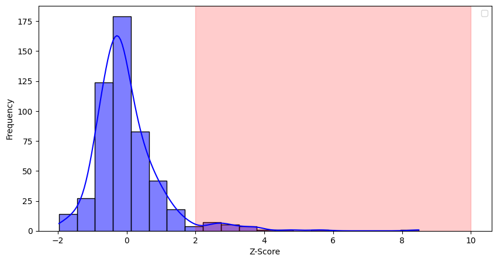

```python
# Call the function to get outliers and z-scores
outliers, zscore = out_zscore2(data_imputada_ok.Renta)

# Create a histogram of the z-scores
plt.figure(figsize=(10, 5))
sb.histplot(zscore, bins=20, kde=True, color='blue')
plt.xlabel('Z-Score')
plt.ylabel('Frequency')
shaded_upper_limit = 10  # Adjust as needed

# Add a shaded region for outliers
if len(outliers) > 0:
    plt.axvspan(xmin=2, xmax=shaded_upper_limit, alpha=0.2, color='red')


plt.legend()
plt.show()
```

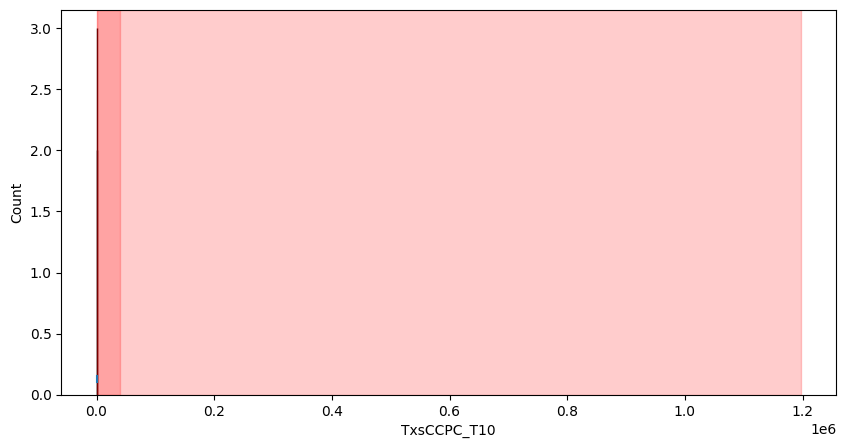

```python
#Se observa que hay una gran
plt.figure(figsize = (10,5))
sb.histplot(data_imputada_ok.TxsCCPC_T10, kde=True, bins=20)
# Add a shaded region for outliers
if len(outliers) > 0:
    plt.axvspan(xmin = lower,xmax= data_imputada_ok.TxsCCPC_T10.min(),alpha=0.2, color='red')
    plt.axvspan(xmin = upper,xmax= data_imputada_ok.TxsCCPC_T10.max(),alpha=0.2, color='red')
```

[figure not shown]

```python
#Se observa que hay una gran
plt.figure(figsize = (10,5))
sb.histplot(elimOutliers.TxsCCPC_T10[elimOutliers.TxsCCPC_T10 < 10], kde=False, bins=20)
# Add a shaded region for outliers
if len(outliers) > 0:
  plt.axvspan(xmin = lower,xmax= elimOutliers.TxsCCPC_T10[elimOutliers.TxsCCPC_T10 < 10].min(),alpha=0.2, color='red')
  plt.axvspan(xmin = upper,xmax= elimOutliers.TxsCCPC_T10[elimOutliers.TxsCCPC_T10 < 10].max(),alpha=0.2, color='red')
```

```python
elimOutliers.TxsCCPC_T10[elimOutliers.TxsCCPC_T10 < 0]
```

```
Series([], Name: TxsCCPC_T10, dtype: float64)
```

[figure not shown]

```python
sb.boxplot(x = data_imputada_ok['TxsCCPC_T10'])
```

```python
elimOutliers = data_imputada_ok.copy()
elimOutliers.TxsCCPC_T10[elimOutliers.TxsCCPC_T10 < 10]
```

```
0    1.0
1    1.0
2    0.0
3    0.0
4    0.0
Name: TxsCCPC_T10, dtype: float64
```

```python
elimOutliers.TxsCCPC_T10[elimOutliers.TxsCCPC_T10 > 10]
```

[output not shown]

[figure not shown]

```python
sb.boxplot(x = elimOutliers.TxsCCPC_T10[elimOutliers.TxsCCPC_T10 < 10])
```

```python
num_outliers = out_iqr(data_imputada_ok.Renta)
num_outliers
```

```
31
```